# exploration

How is the relationship between loan status and employmentstatus?

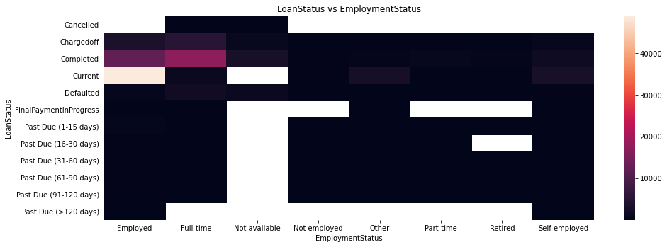

```python
fig = plt.figure()
ax = fig.add_axes([.0, .0, 2, 1])
ct_counts = df.groupby(['LoanStatus', 'EmploymentStatus']).size()
ct_counts = ct_counts.reset_index(name='count')

ct_counts = ct_counts.pivot(index = 'LoanStatus', columns = 'EmploymentStatus', values = 'count')
ax.set_title('LoanStatus vs EmploymentStatus')
sb.heatmap(ct_counts)
```

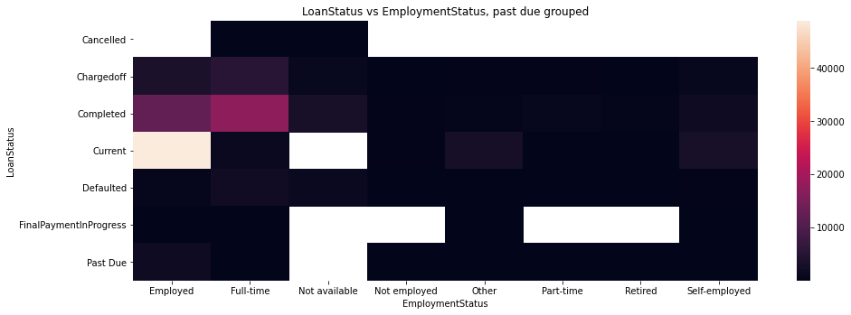

```python
fig = plt.figure()
ax = fig.add_axes([.0, .0, 2, 1])
ct_counts = df_group_pastDue.groupby(['LoanStatus', 'EmploymentStatus']).size()
ct_counts = ct_counts.reset_index(name='count')
ct_counts = ct_counts.pivot(index = 'LoanStatus', columns = 'EmploymentStatus', values = 'count')
ax.set_title('LoanStatus vs EmploymentStatus, past due grouped')
sb.heatmap(ct_counts)
```

**Observation:** The largest group of loans are from employed + current loan status. Then we have 2. Full-time + completed 3. Employed + completed 4. Full-time + chargedoff.

**LoanStatus vs EmploymentStatusDuration**

How is the relationship bewtween loan status and employedment status duration?

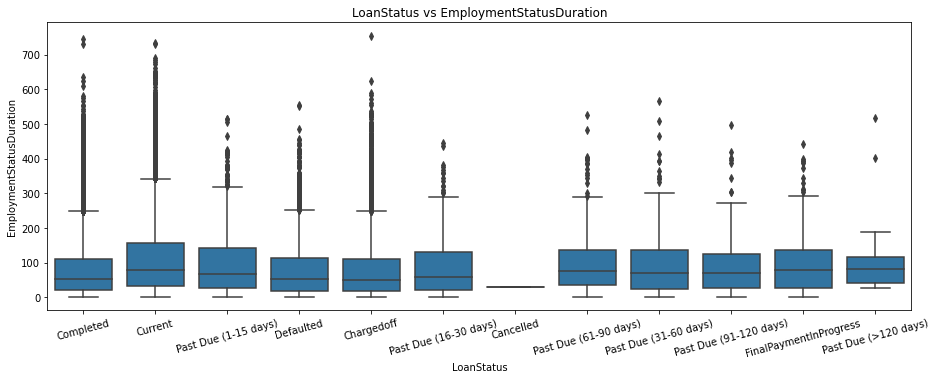

```python
fig = plt.figure()
ax = fig.add_axes([.0, .0, 2, 1])

sb.boxplot(data=df, x='LoanStatus', y='EmploymentStatusDuration', color=base_color)
ax.set_title('LoanStatus vs EmploymentStatusDuration')
plt.xticks(rotation=15);
```

```
(0.0, 200.0)
```

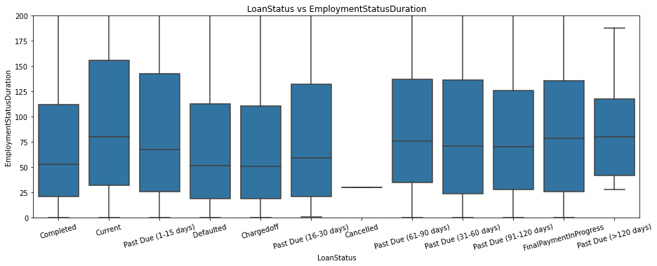

```python
fig = plt.figure()
ax = fig.add_axes([.0, .0, 2, 1])

sb.boxplot(data=df, x='LoanStatus', y='EmploymentStatusDuration', color=base_color)
ax.set_title('LoanStatus vs EmploymentStatusDuration')
plt.xticks(rotation=15);
plt.ylim(0, 200)
```

**Observation**: We have current load status be the largest employment status duration, and cancelled are smallest.

**LoanStatus vs DebtToIncomeRatio**

What is the relationship between loan status and debt to income ratio?

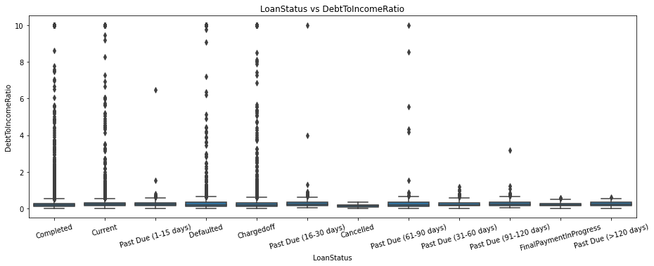

```python
fig = plt.figure()
ax = fig.add_axes([.0, .0, 2, 1])

sb.boxplot(data=df, x='LoanStatus', y='DebtToIncomeRatio', color=base_color)
ax.set_title('LoanStatus vs DebtToIncomeRatio')
plt.xticks(rotation=15);
```

```
(0.0, 0.6)
```

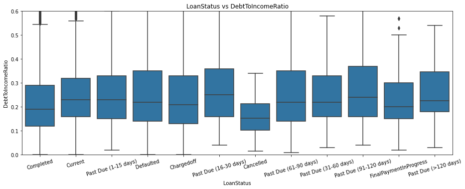

```python
fig = plt.figure()
ax = fig.add_axes([.0, .0, 2, 1])

sb.boxplot(data=df, x='LoanStatus', y='DebtToIncomeRatio', color=base_color)
ax.set_title('LoanStatus vs DebtToIncomeRatio')
plt.xticks(rotation=15);
plt.ylim(0, 0.6)
```

```
(0.0, 0.6)
```

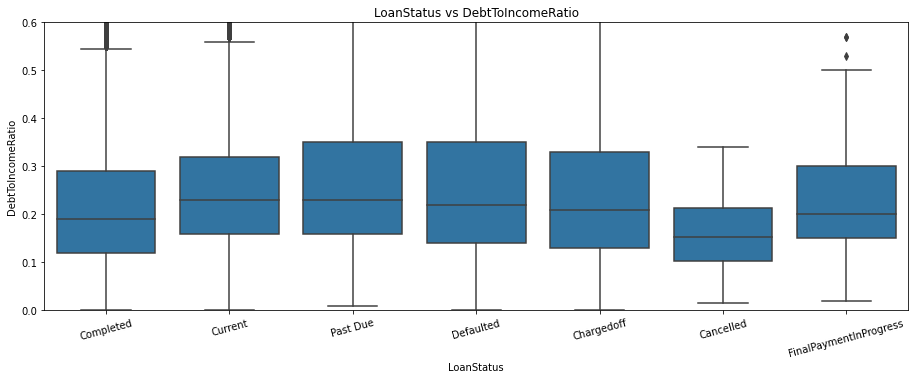

```python
fig = plt.figure()
ax = fig.add_axes([.0, .0, 2, 1])

sb.boxplot(data=df_group_pastDue, x='LoanStatus', y='DebtToIncomeRatio', color=base_color)
ax.set_title('LoanStatus vs DebtToIncomeRatio')
plt.xticks(rotation=15);
plt.ylim(0, 0.6)
```

**Observation**: We have cancelled load status has the lowest debt to income ratio and past due(16-30 days) have the largest debt to income ratio.

**LoanStatus vs MonthlyLoanPayment**

What is the relationship between loan status and monthly loan payment?

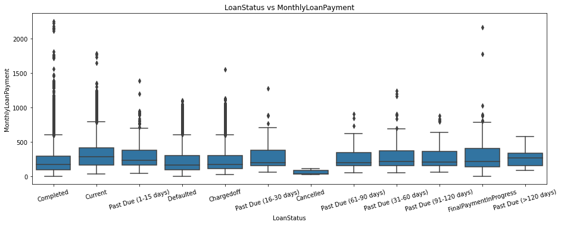

```python
fig = plt.figure()
ax = fig.add_axes([.0, .0, 2, 1])

sb.boxplot(data=df, x='LoanStatus', y='MonthlyLoanPayment', color=base_color)
ax.set_title('LoanStatus vs MonthlyLoanPayment')
plt.xticks(rotation=15);
```

```
(0.0, 500.0)
```

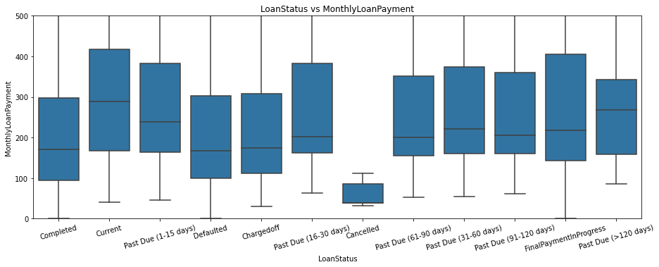

```python
fig = plt.figure()
ax = fig.add_axes([.0, .0, 2, 1])

sb.boxplot(data=df, x='LoanStatus', y='MonthlyLoanPayment', color=base_color)
plt.xticks(rotation=15);
ax.set_title('LoanStatus vs MonthlyLoanPayment')
plt.ylim(0, 500)
```

**Observation:** We have **cancelled** load status has the lowest monthly loan payment and **current** have the largest monthly loan payment.

**LoanStatus vs Investors**

How is the relationship bewtween loan status and investors?

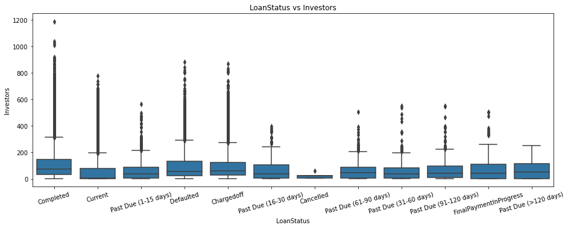

```python
fig = plt.figure()
ax = fig.add_axes([.0, .0, 2, 1])

sb.boxplot(data=df, x='LoanStatus', y='Investors', color=base_color)
ax.set_title('LoanStatus vs Investors')
plt.xticks(rotation=15);
```

```
(0.0, 200.0)
```

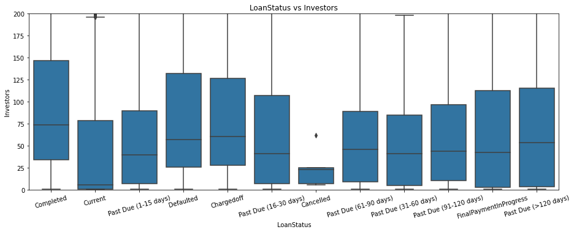

```python
fig = plt.figure()
ax = fig.add_axes([.0, .0, 2, 1])

sb.boxplot(data=df, x='LoanStatus', y='Investors', color=base_color)
plt.xticks(rotation=15);
ax.set_title('LoanStatus vs Investors')
plt.ylim(0, 200)
```

**Observation**: We have current load status have fewest investors, and completed load status have most investors.

**BorrowerAPR vs BorrowerState**

What is the relationship between borrower APR and borrower state? We might also want to find the difference of big borrowerAPR and small borrowerAPR

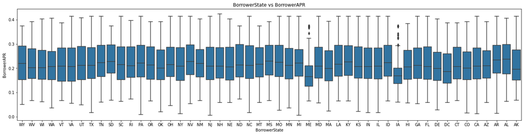

```python
fig = plt.figure()
ax = fig.add_axes([.0, .0, 3, 1])
my_order = df.groupby(by=["BorrowerState"])["BorrowerAPR"].mean().iloc[::-1].index
ax.set_title('BorrowerState vs BorrowerAPR')
sb.boxplot(data=df, y='BorrowerAPR', x='BorrowerState', color=base_color,order=my_order)
```

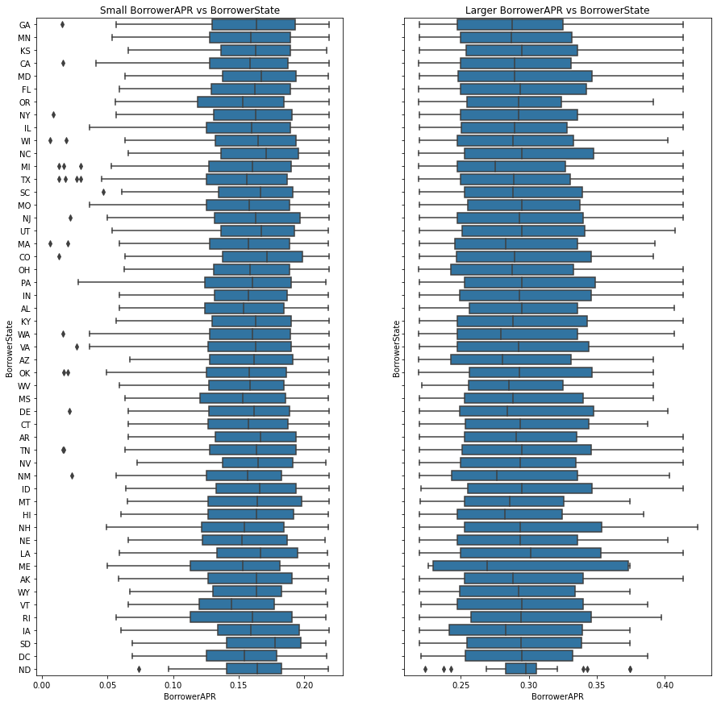

```python
fig, axes = plt.subplots(1, 2, figsize=(15, 15), sharey=True)

df_APR_small = df[df['BorrowerAPR'] <= df['BorrowerAPR'].mean()]
df_APR_big = df[df['BorrowerAPR'] > df['BorrowerAPR'].mean()]

sb.boxplot(ax=axes[0],data=df_APR_small, x='BorrowerAPR', y='BorrowerState', color=base_color)
axes[0].set_title('Small BorrowerAPR vs BorrowerState')

sb.boxplot(ax=axes[1],data=df_APR_big, x='BorrowerAPR', y='BorrowerState', color=base_color)
axes[1].set_title('Larger BorrowerAPR vs BorrowerState')
```

**Obversation:** Although we have the largest amount of loan in CA, CA is not having the highest borrower APR.

The higher Borrower APR are from AR and AL and MS. The lower Borrower APR are from ME and IA.

we notice that, among smaller BorrowerAPR and larger BorrowerAPR, the highest and lowest states are different.

Among the larger Borrower APR, the highest is LA, lowest is ME. Among the smaller Borrower APR, the highest is SD, lowest is VT.

**BorrowerAPR vs EmploymentStatus**

What is the relationship between borrower APR and employment status?

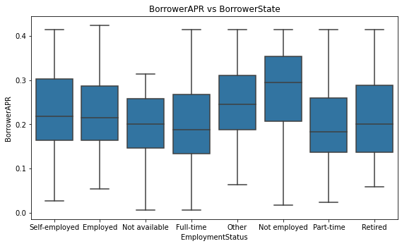

```python
base_color = sb.color_palette()[0]
fig = plt.figure()
ax = fig.add_axes([.0, .0, 1.2, 1])

sb.boxplot(data=df, y='BorrowerAPR', x='EmploymentStatus', color=base_color)
ax.set_title('BorrowerAPR vs BorrowerState')
```

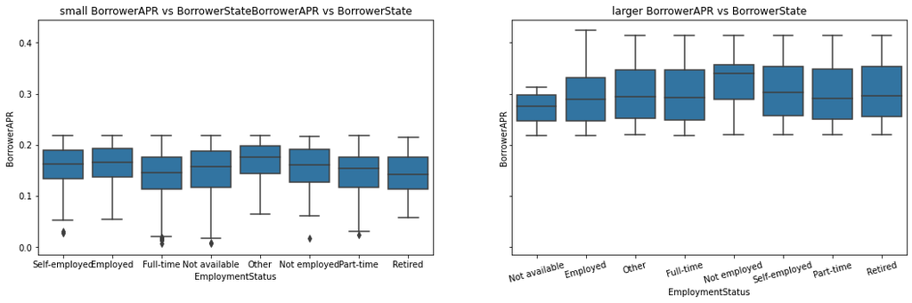

```python
fig, axes = plt.subplots(1, 2, figsize=(18, 5), sharey=True)

sb.boxplot(ax=axes[0],data=df_APR_small, y='BorrowerAPR', x='EmploymentStatus', color=base_color)
axes[0].set_title('small BorrowerAPR vs BorrowerStateBorrowerAPR vs BorrowerState')
plt.xticks(rotation=15);

sb.boxplot(ax=axes[1],data=df_APR_big, y='BorrowerAPR', x='EmploymentStatus', color=base_color)
axes[1].set_title('larger BorrowerAPR vs BorrowerState')
plt.xticks(rotation=15);
```

**Observation**: Among smaller BorrowerAPR and larger BorrowerAPR, the most and least employment status are different too.

**BorrowerAPR vs EmploymentStatusDuration**

What is the relationship bewtween borrower APR and employment status duration?

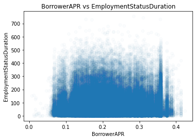

```python
plt.scatter(data = df, x = 'BorrowerAPR', y = 'EmploymentStatusDuration', alpha=1/50);

plt.title('BorrowerAPR vs EmploymentStatusDuration')
plt.xlabel('BorrowerAPR')
plt.ylabel('EmploymentStatusDuration')
```

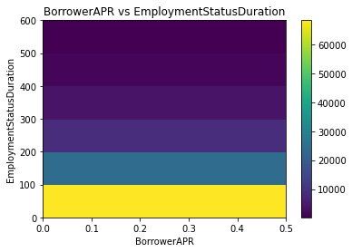

```python
bins_x = np.arange(0.0, 0.5+0.3, 0.5)
bins_y = np.arange(0, 600+100, 100)

plt.hist2d(data = df, x = 'BorrowerAPR', y = 'EmploymentStatusDuration', cmin=0.5, bins = [bins_x, bins_y])
plt.colorbar()
plt.xlabel('BorrowerAPR')
plt.ylabel('EmploymentStatusDuration');
plt.title('BorrowerAPR vs EmploymentStatusDuration')
```

**Observation**: There is a not clear obvious normal distribution between borrower apr and employment status duration.

**BorrowerAPR vs DebtToIncomeRatio**

What is the relationship between BorrowerAPR and DebtToIncomeRatio?

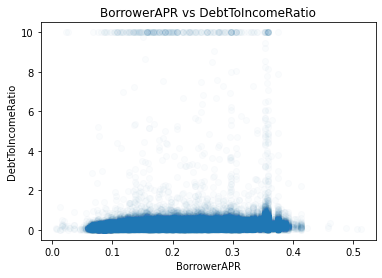

```python
plt.scatter(data = df, x = 'BorrowerAPR', y = 'DebtToIncomeRatio', alpha=1/50);
plt.xlabel('BorrowerAPR')
plt.ylabel('DebtToIncomeRatio')
plt.title('BorrowerAPR vs DebtToIncomeRatio')
```

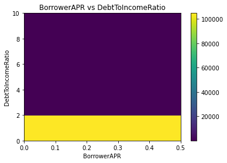

```python
bins_x = np.arange(0.0, 0.5+0.3, 0.5)
bins_y = np.arange(0, 10+2, 2)

plt.hist2d(data = df, x = 'BorrowerAPR', y = 'DebtToIncomeRatio', cmin=0.5, bins = [bins_x, bins_y])
plt.colorbar()
plt.xlabel('BorrowerAPR')
plt.ylabel('DebtToIncomeRatio');
plt.title('BorrowerAPR vs DebtToIncomeRatio')
```

**Observation**: Mostly debt to income ratio are around 0 - 1, there are no clear relationship between borrower APR and debt to income ratio.

**BorrowerAPR vs StatedMonthlyIncome**

What is the relationship between borrowerAPR and state monthly income?

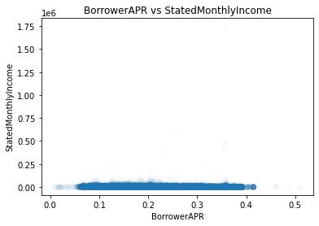

```python
plt.scatter(data = df, x = 'BorrowerAPR', y = 'StatedMonthlyIncome', alpha=1/50);
plt.xlabel('BorrowerAPR')
plt.ylabel('StatedMonthlyIncome')
plt.title('BorrowerAPR vs StatedMonthlyIncome')
```

**BorrowerAPR vs MonthlyLoanPayment**

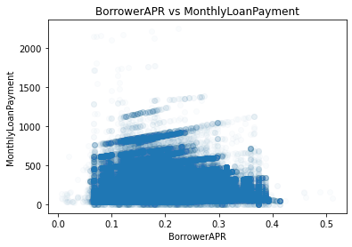

```python
plt.scatter(data = df, x = 'BorrowerAPR', y = 'MonthlyLoanPayment', alpha=1/50);
plt.xlabel('BorrowerAPR')
plt.ylabel('MonthlyLoanPayment')
plt.title('BorrowerAPR vs MonthlyLoanPayment')
```

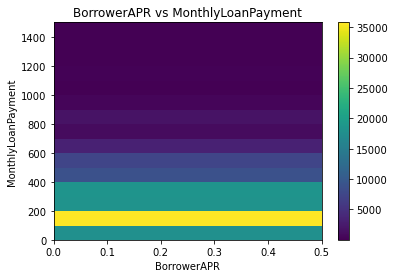

```python
bins_x = np.arange(0.0, 0.5+0.3, 0.5)
bins_y = np.arange(0, 1500+100, 100)

plt.hist2d(data = df, x = 'BorrowerAPR', y = 'MonthlyLoanPayment', cmin=0.5, bins = [bins_x, bins_y])
plt.colorbar()
plt.xlabel('BorrowerAPR')
plt.ylabel('MonthlyLoanPayment');
plt.title('BorrowerAPR vs MonthlyLoanPayment')
```

**Observation**: There is a not obvious right skewed relationship between borrower apr and monthly load payment. Mostly Monthly loan payment are 100-200.

**BorrowerAPR vs Investors**

What is the relationship between borrower APR and investors?

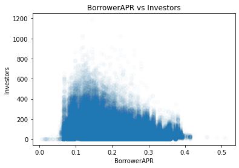

```python
plt.scatter(data = df, x = 'BorrowerAPR', y = 'Investors', alpha=1/50);
plt.xlabel('BorrowerAPR')
plt.ylabel('Investors');
plt.title('BorrowerAPR vs Investors')
```

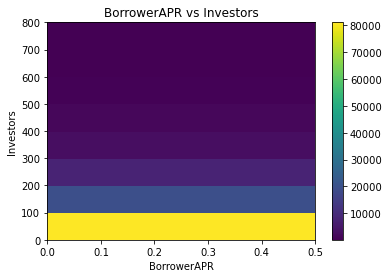

```python
bins_x = np.arange(0.0, 0.5+0.3, 0.5)
bins_y = np.arange(0, 800+100, 100)

plt.hist2d(data = df, x = 'BorrowerAPR', y = 'Investors', cmin=0.5, bins = [bins_x, bins_y])
plt.colorbar()
plt.xlabel('BorrowerAPR');
plt.ylabel('Investors');
plt.title('BorrowerAPR vs Investors')
```

**Observation**: There is a not obvious right skewed relationship between borrower apr and investors. Mostly investors are around 1-200.

**BorrowerRate vs BorrowerState**

What is the relationship between borrower rate and borrower state?

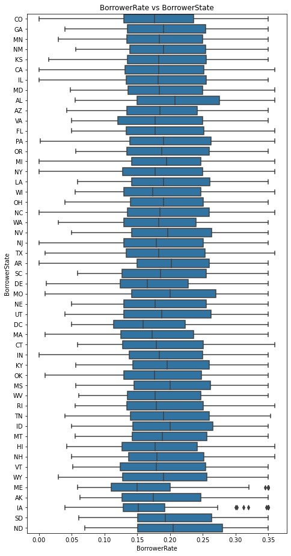

```python
base_color = sb.color_palette()[0]
fig = plt.figure()
ax = fig.add_axes([.0, .0, 1, 3])

sb.boxplot(data=df, x='BorrowerRate', y='BorrowerState', color=base_color)
plt.xlabel('BorrowerRate');
plt.ylabel('BorrowerState');
plt.title('BorrowerRate vs BorrowerState')
```

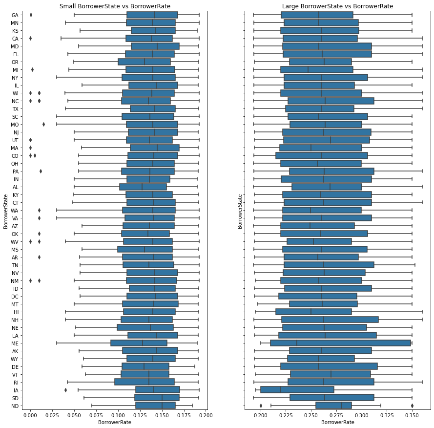

```python
df_Rate_small = df[df['BorrowerRate'] <= df['BorrowerRate'].mean()]
df_Rate_big = df[df['BorrowerRate'] > df['BorrowerRate'].mean()]

fig, axes = plt.subplots(1, 2, figsize=(15, 15), sharey=True)

sb.boxplot(ax=axes[0],data=df_Rate_small, y='BorrowerState', x='BorrowerRate', color=base_color)
axes[0].set_title('Small BorrowerState vs BorrowerRate')

sb.boxplot(ax=axes[1],data=df_Rate_big, y='BorrowerState', x='BorrowerRate', color=base_color)
axes[1].set_title('Large BorrowerState vs BorrowerRate')
```

MD, SD, ND have higher borrower rate among lower borrower rate. AL, OR have lower borrower rate among lower borrower rate.

**BorrowerRate vs Investors**

What is the relationship between borrower rate and investors?

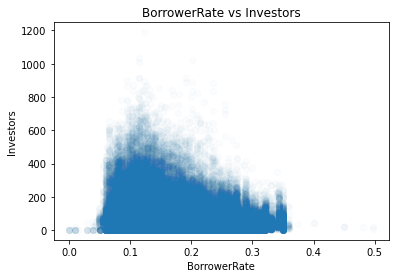

```python
plt.scatter(data = df, x = 'BorrowerRate', y = 'Investors', alpha=1/50);
plt.xlabel('BorrowerRate')
plt.ylabel('Investors');
plt.title('BorrowerRate vs Investors')
```

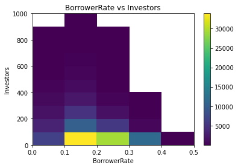

```python
bins_x = np.arange(0.0, 0.5+0.1, 0.1)
bins_y = np.arange(0, 1000+100, 100)

plt.hist2d(data = df, x = 'BorrowerRate', y = 'Investors', cmin=0.5, bins = [bins_x, bins_y])
plt.colorbar()
plt.xlabel('BorrowerRate');
plt.ylabel('Investors');
plt.title('BorrowerRate vs Investors')
```

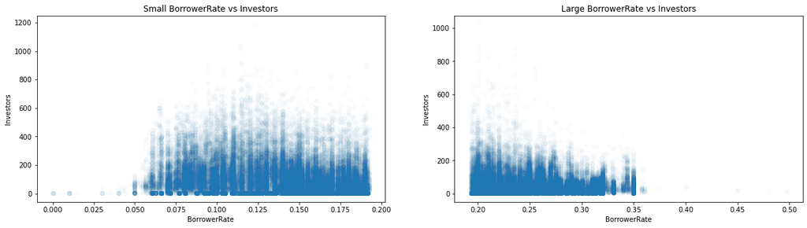

```python
plt.figure(figsize = [20, 5])

plt.subplot(1, 2, 1)
plt.scatter(data = df_Rate_small, x = 'BorrowerRate', y = 'Investors', alpha=1/50);
plt.title('Small BorrowerRate vs Investors')
plt.xlabel('BorrowerRate')
plt.ylabel('Investors');

plt.subplot(1, 2, 2)
plt.scatter(data = df_Rate_big, x = 'BorrowerRate', y = 'Investors', alpha=1/50);
plt.title('Large BorrowerRate vs Investors')
plt.xlabel('BorrowerRate')
plt.ylabel('Investors');
```

**Observation**: There is a right skewed relationship between BorrowerRate and investors.

## Multivariate Exploration

Main variable of interest:

- LoanStatus(loan’s outcome)
- BorrowerAPR
- BorrowerRate

**LoanStatus vs BorrowerState vs BorrowerAPR**

We would like to know the relationship between load status, borrower state and borrower APR. First take a look at those state that have different behaviour in previous analysis(MD, SD, ND, AL, OR, IA, LA, ME, VT).

```python
df_MD = df_group_pastDue[df_group_pastDue['BorrowerState'] == 'MD']
df_SD = df_group_pastDue[df_group_pastDue['BorrowerState'] == 'SD']
df_ND = df_group_pastDue[df_group_pastDue['BorrowerState'] == 'ND']
df_AL = df_group_pastDue[df_group_pastDue['BorrowerState'] == 'AL']
df_OR = df_group_pastDue[df_group_pastDue['BorrowerState'] == 'OR']
df_IA = df_group_pastDue[df_group_pastDue['BorrowerState'] == 'IA']
df_LA = df_group_pastDue[df_group_pastDue['BorrowerState'] == 'LA']
df_ME = df_group_pastDue[df_group_pastDue['BorrowerState'] == 'ME']
df_VT = df_group_pastDue[df_group_pastDue['BorrowerState'] == 'VT']
df_AR = df_group_pastDue[df_group_pastDue['BorrowerState'] == 'AR']

frames = [df_MD, df_SD, df_ND,df_AL,df_OR,df_IA,df_LA,df_ME,df_VT,df_AR]
result = pd.concat(frames)
```

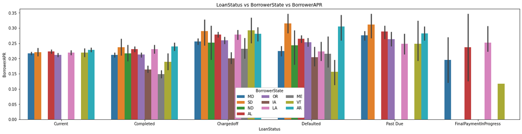

```python
fig = plt.figure()
ax = fig.add_axes([.0, .0, 3, 1])

ax = sb.barplot(data = result, x = 'LoanStatus', y = 'BorrowerAPR', hue = 'BorrowerState')
ax.legend(loc = 8, ncol = 3, framealpha = 1, title = 'BorrowerState')
plt.title('LoanStatus vs BorrowerState vs BorrowerAPR')
plt.xlabel('LoanStatus')
plt.ylabel('BorrowerAPR');
```

**Observation**:The higher Borrower APR are from AR and AL. AR has a higher borrower AR in defaulted load status. AR and AL have a higher borrower AR in past due load status.

The lower Borrower APR are from ME and IA. ME and IA in all load stauts are having a load borrower APR.

Amoung the smaller Borrower APR, the highest is SD. And SD have a high borrower APR in defaulted and past due load status.

**LoanStatus vs EmploymentStatus vs BorrowerAPR**

What is the relationship between load status, employment status and borrower APR.

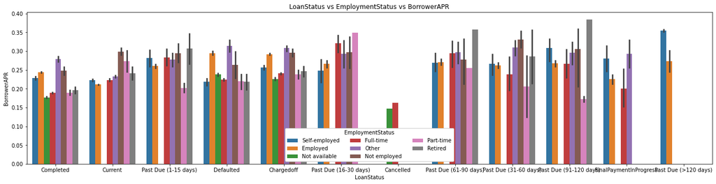

```python
fig = plt.figure()
ax = fig.add_axes([.0, .0, 3, 1])

ax = sb.barplot(data = df, x = 'LoanStatus', y = 'BorrowerAPR', hue = 'EmploymentStatus')
ax.legend(loc = 8, ncol = 3, framealpha = 1, title = 'EmploymentStatus')
plt.title('LoanStatus vs EmploymentStatus vs BorrowerAPR')
plt.xlabel('LoanStatus')
plt.ylabel('BorrowerAPR');
```

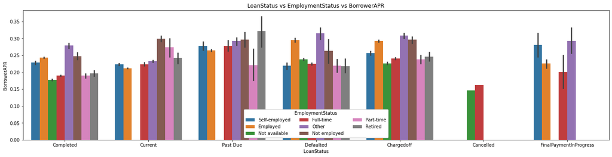

```python
fig = plt.figure()
ax = fig.add_axes([.0, .0, 3, 1])

ax = sb.barplot(data = df_group_pastDue, x = 'LoanStatus', y = 'BorrowerAPR', hue = 'EmploymentStatus')
ax.legend(loc = 8, ncol = 3, framealpha = 1, title = 'EmploymentStatus')
plt.title('LoanStatus vs EmploymentStatus vs BorrowerAPR')
plt.xlabel('LoanStatus')
plt.ylabel('BorrowerAPR');
```